# 30DayMapChallenge - Hexagons: Visualizing State Data

Macy Trout

2024-11-30

# Map Title: Most Googled NFL Teams by State

Description: This map visualizes the most googled NFL teams across each U.S. state based on data from Google Trends. Each state is represented by a hexagon, color-coded to indicate the most popular NFL team within that state over the last 30 days.

Design Considerations: - Hexagonal Grid: The hexagonal map was chosen for its visually clean and consistent layout, eliminating the distortion caused by varying state sizes on traditional geographic maps.

- Color Palette: Distinct team colors were used to ensure clear identification of each team, with shades chosen to align with official team branding.
- Dark Background: A dark greige background was selected to create contrast and make the vibrant team colors pop, enhancing visual appeal.
- State Labels: Abbreviations for each state were added to improve map readability without overwhelming the design.
- Legend Placement: The legend was positioned at the top in a horizontal format for better integration into the overall layout, ensuring it doesn’t interfere with the map visualization.
- Font Choices: Playfair was used for titles and captions to give the map a modern and elegant appearance, while Lato was used for in-map text for clarity and simplicity.

The goal was to create an engaging, visually appealing, and easily interpretable map that highlights regional NFL team popularity at a glance. The design balances aesthetics and functionality, ensuring the data is easy to understand while providing an appealing visual narrative.

```r
library(tidyverse)
library(gtrendsR)
library(sf)
library(rcartocolor)
library(showtext)


hex_grid_path <- "/Users/MacyTrout/Desktop/R Studio Files/30 day map challenge/Hexagon/us_states_hexgrid.geojson.json"


hex_grid <- st_read(hex_grid_path, quiet=TRUE) %>%
  mutate(state_abbr = iso3166_2)

nfl_teams <- c("Philadelphia Eagles", "Kansas City Chiefs", "Dallas Cowboys", "San Francisco 49ers")
nfl_trends <- gtrends(keyword = nfl_teams, geo = "US", time = "today 1-m")$interest_by_region


nfl_trends <- nfl_trends %>%
  mutate(
    state_abbr = usdata::state2abbr(location),
    state_abbr = ifelse(location == "District of Columbia", "DC", state_abbr),
    hits = replace_na(as.numeric(hits), 0)  # Replace NA hits with 0
  )

missing_abbr <- setdiff(hex_grid$state_abbr, nfl_trends$state_abbr)


nfl_trends <- nfl_trends %>%
  group_by(state_abbr) %>%
  top_n(1, hits)

hex_map_data <- hex_grid %>%
  left_join(nfl_trends, by = "state_abbr")


hex_map_data <- hex_map_data %>%
  mutate(keyword = replace_na(keyword, "No Data"))
```

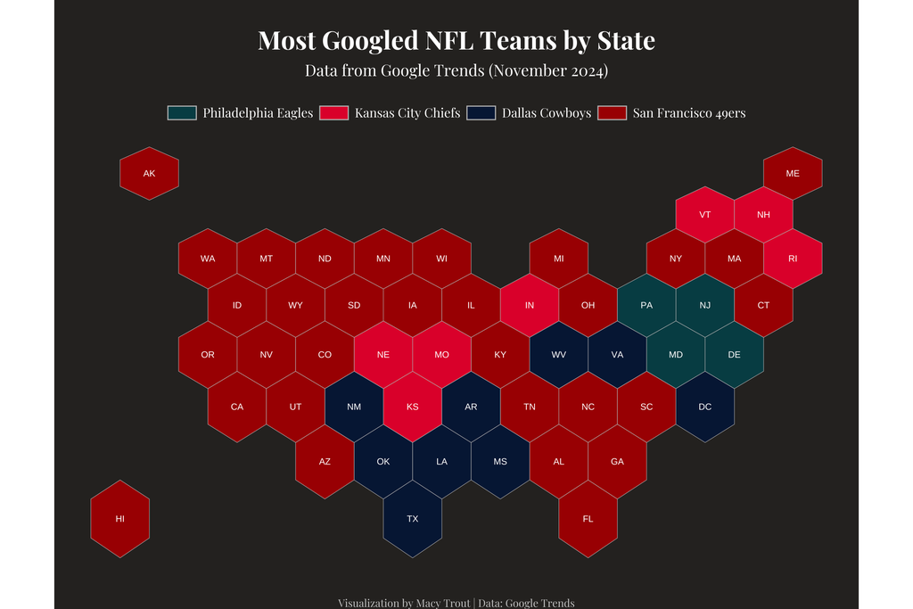

```r
library(tidyverse)
library(sf)
library(rcartocolor)
library(showtext)


font_add_google("Playfair Display", "Playfair")
showtext_auto()


state_labels <- hex_grid %>%
  mutate(geometry = st_centroid(geometry)) %>%
  st_coordinates() %>%  # Extract coordinates
  as.data.frame() %>%
  mutate(state_abbr = hex_grid$state_abbr)

hex_map <- ggplot(hex_map_data) +
  geom_sf(aes(fill = keyword), color = "grey", size = 0.3) +
  scale_fill_manual(
    values = c(
      "Philadelphia Eagles" = "#004C54",
      "Kansas City Chiefs" = "#E31837",
      "Dallas Cowboys" = "#041E42",
      "San Francisco 49ers" = "#AA0000",
      "No Data" = "grey60"
    ),
    breaks = c(
      "Philadelphia Eagles",
      "Kansas City Chiefs",
      "Dallas Cowboys",
      "San Francisco 49ers"
    ),
    labels = c(
      "Philadelphia Eagles",
      "Kansas City Chiefs",
      "Dallas Cowboys",
      "San Francisco 49ers"
    ),
    name = NULL
  ) +
  geom_text(
    data = state_labels,
    aes(X, Y, label = state_abbr),
    family = "Lato", size = 3, color = "white"
  ) +
  labs(
    title = "Most Googled NFL Teams by State",
    subtitle = "Data from Google Trends (November 2024)",
    caption = "Visualization by Macy Trout | Data: Google Trends"
  ) +
  theme_void() +
  theme(
    panel.background = element_rect(fill = "#2F2C2A", color = NA),
    plot.background = element_rect(fill = "#2F2C2A", color = NA),

    plot.title.position = "plot",
    plot.caption.position = "plot",

    plot.title = element_text(
      family = "Playfair", size = 24, face = "bold", hjust = 0.5,
      margin = margin(t = 30, b = 10),
      color = "white"
    ),
    plot.subtitle = element_text(
      family = "Playfair", size = 15, hjust = 0.5, margin = margin(b = 25),
      color = "white"
    ),

    plot.caption = element_text(
      family = "Playfair", size = 10, hjust = 0.5, color = "grey80", margin = margin(t = 20)
    ),


    legend.position = "top",
    legend.direction = "horizontal",
    legend.title = element_blank(),
    legend.text = element_text(
      family = "Playfair", size = 12, color = "white"
    ),
    legend.key.height = unit(0.5, "cm"),
    legend.key.width = unit(1.0, "cm")
  )


print(hex_map)
```